# Classifying Tomato Leaf Images

12/07/2022

## Background

- Tomato Leaf Image data set
- From Kaggle: https://www.kaggle.com/datasets/ashishmotwani/tomato
- Over 32k images, with 11 categories (1 healthy, rest diseases)
- Images already split ~80/20 for train test
- Classification is our goal

## Some Examples of the Data

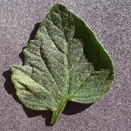

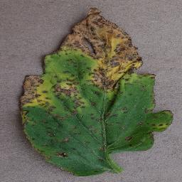

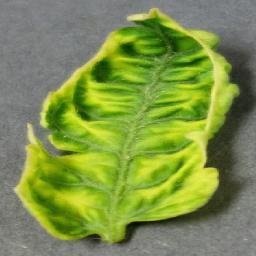

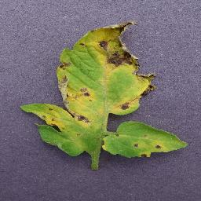

## Our Goal

- Correctly classify images with 95% accuracy in one of 11 categories
- Using Neural Net or K-means cluster algorithm
- Optimize the algorithms as needed to get to 95%

## Technical Details/Shape of Data

- 255 * 255 pixel images
- RGB
- Images randomly rotated
- Some in-the-wild, some in-the-lab
- Wide variety of quality, contrast, brightness, etc
- No declared single source

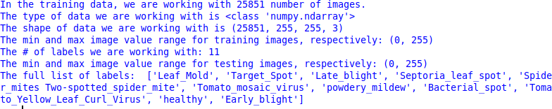

## More Examples of the Data

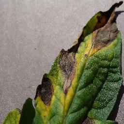

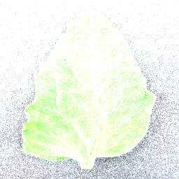

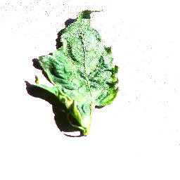

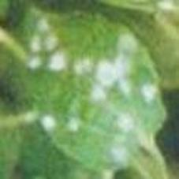

## Neural Net

- Grid Search: 32 architectures tested total
- Trying all 8 default tensor flow optimizers
- Tested with 128 neurons for all layers, except for the final test
- Tested 1, 2, 3 hidden layers, and a fourth test with only 32 neurons and 1 hidden layer

## 1 Hidden Layer Results

```r
results[results$Test=="1layernn",]
```

```
##       Test Optimizer Accuracy
## 1 1layernn       SGD    0.225
## 2 1layernn   RMSprop    0.225
## 3 1layernn      Adam    0.225
## 4 1layernn  Adadelta    0.460
## 5 1layernn   Adagrad    0.360
## 6 1layernn    Adamax    0.410
## 7 1layernn     Nadam    0.350
## 8 1layernn      Ftrl    0.225
```

## 2 Hidden Layers Results

```r
results[results$Test=="2layernn",]
```

```
##        Test Optimizer Accuracy
## 9  2layernn       SGD    0.225
## 10 2layernn   RMSprop    0.225
## 11 2layernn      Adam    0.500
## 12 2layernn  Adadelta    0.450
## 13 2layernn   Adagrad    0.450
## 14 2layernn    Adamax    0.440
## 15 2layernn     Nadam    0.510
## 16 2layernn      Ftrl    0.225
```

## 3 Hidden Layers Results

```r
results[results$Test=="3layernn",]
```

```
##        Test Optimizer Accuracy
## 17 3layernn       SGD    0.490
## 18 3layernn   RMSprop    0.225
## 19 3layernn      Adam    0.525
## 20 3layernn  Adadelta    0.474
## 21 3layernn   Adagrad    0.460
## 22 3layernn    Adamax    0.510
## 23 3layernn     Nadam    0.460
## 24 3layernn      Ftrl    0.225
```

## 1 Hidden Layer, Fewer Neurons Results

```r
results[results$Test=="32neuronnn",]
```

```
##          Test Optimizer Accuracy
## 25 32neuronnn       SGD    0.225
## 26 32neuronnn   RMSprop    0.225
## 27 32neuronnn      Adam    0.225
## 28 32neuronnn  Adadelta    0.394
## 29 32neuronnn   Adagrad    0.225
## 30 32neuronnn    Adamax    0.225
## 31 32neuronnn     Nadam    0.225
## 32 32neuronnn      Ftrl    0.225
```

## Neural Net Overall Results

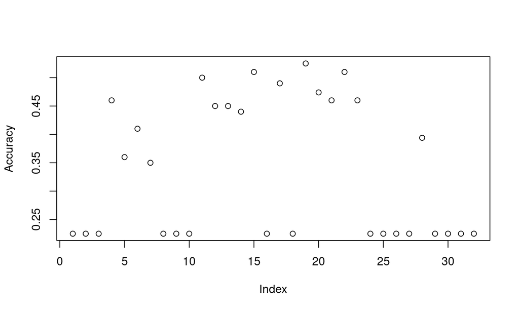

```r
plot(results$Accuracy, ylab="Accuracy")
```

## Neural Net Results Cntd

- The best was a 3 hidden layer, 128 neuron, Adam optimizer
- Still nowhere near our goal of 95%
- Clear arc to the accuracy: more neurons, more layers was working
- Started running out of computational power to go further

## K-means Clustering

- 8 clusters tested in total
- 11, 22, 44, 66, 88, 99, 110, and 121 clusters tested
- Also started running into computational problems with more than 121 clusters

## K-means Clustering Results

```r
kmeans_results
```

```
##   Num_Clusters Accuracy
## 1           11    0.300
## 2           22    0.355
## 3           44    0.415
## 4           66    0.410
## 5           88    0.430
## 6           99    0.443
## 7          110    0.445
## 8          121    0.447
```

## K-means Clustering Results Cntd

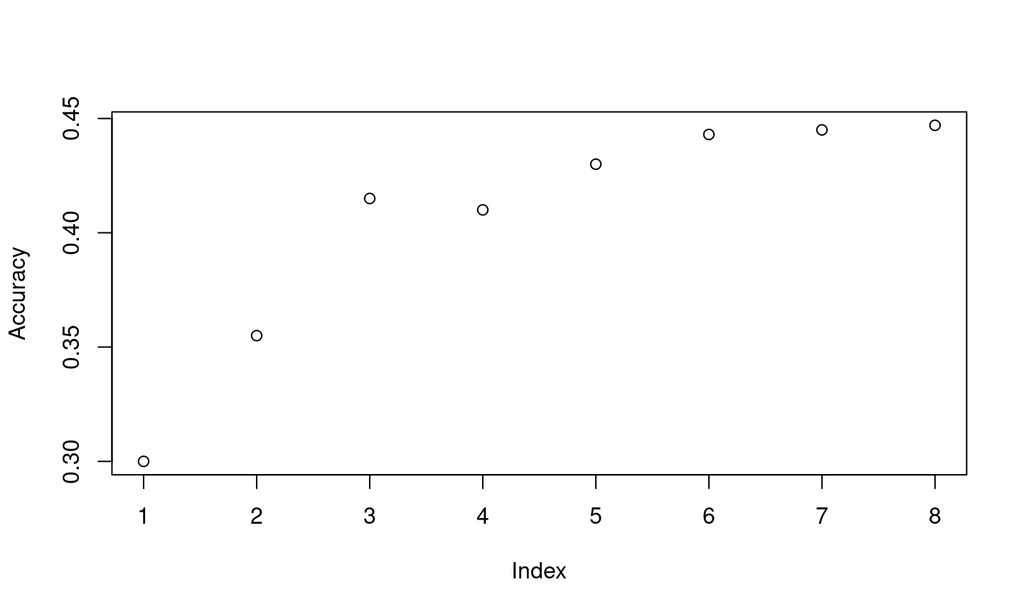

```r
plot(kmeans_results$Accuracy, ylab="Accuracy")
```

## Unexpected K-means results

- 121 clusters is better than 11 clusters?
- Visualization is difficult, and hard to interpret its meaning
- Accuracy is 50% better when there are 11^2 clusters
- Again, computational challenges are preventing me from going further

## Discussion

- Computational limits were preventing further exploration
- Did not reach our goal of 95%- nowhere close
- Our elbow graph with k-means clustering seemed to suggest its accuracy had peaked
- Neural nets, more neurons and more layers, seem to be the best avenue for further improvement in accuracy, and did not seem to be done improving
- Really great dataset- more optimization needed